# Risk Factor Analysis

## Outcome Variable

**Outcome Variable:** stunted

## Predictor Variables

**Intervention Variable:** mbmi

**Adjustment Set:**

unadjusted

## Stratifying Variables

The analysis was stratified on these variable(s):

- agecat
- studyid

The following strata were considered:

- agecat: 12 months, studyid: ki0047075b-MAL-ED
- agecat: 12 months, studyid: ki1017093-NIH-Birth
- agecat: 12 months, studyid: ki1017093b-PROVIDE
- agecat: 12 months, studyid: ki1017093c-NIH-Crypto
- agecat: 12 months, studyid: ki1066203-TanzaniaChild2
- agecat: 12 months, studyid: ki1126311-ZVITAMBO
- agecat: 12 months, studyid: ki1148112-LCNI-5
- agecat: 18 months, studyid: ki0047075b-MAL-ED
- agecat: 18 months, studyid: ki1017093-NIH-Birth
- agecat: 18 months, studyid: ki1017093b-PROVIDE
- agecat: 18 months, studyid: ki1017093c-NIH-Crypto
- agecat: 18 months, studyid: ki1066203-TanzaniaChild2
- agecat: 18 months, studyid: ki1126311-ZVITAMBO
- agecat: 18 months, studyid: ki1148112-LCNI-5
- agecat: 24 months, studyid: ki0047075b-MAL-ED
- agecat: 24 months, studyid: ki1017093-NIH-Birth
- agecat: 24 months, studyid: ki1017093b-PROVIDE
- agecat: 24 months, studyid: ki1017093c-NIH-Crypto
- agecat: 24 months, studyid: ki1066203-TanzaniaChild2
- agecat: 24 months, studyid: ki1126311-ZVITAMBO
- agecat: 24 months, studyid: ki1148112-LCNI-5
- agecat: 3 months, studyid: ki0047075b-MAL-ED
- agecat: 3 months, studyid: ki1017093-NIH-Birth
- agecat: 3 months, studyid: ki1017093b-PROVIDE
- agecat: 3 months, studyid: ki1017093c-NIH-Crypto
- agecat: 3 months, studyid: ki1066203-TanzaniaChild2
- agecat: 3 months, studyid: ki1126311-ZVITAMBO
- agecat: 6 months, studyid: ki0047075b-MAL-ED
- agecat: 6 months, studyid: ki1017093-NIH-Birth
- agecat: 6 months, studyid: ki1017093b-PROVIDE
- agecat: 6 months, studyid: ki1017093c-NIH-Crypto
- agecat: 6 months, studyid: ki1066203-TanzaniaChild2
- agecat: 6 months, studyid: ki1126311-ZVITAMBO
- agecat: 6 months, studyid: ki1148112-LCNI-5
- agecat: 9 months, studyid: ki0047075b-MAL-ED
- agecat: 9 months, studyid: ki1017093-NIH-Birth
- agecat: 9 months, studyid: ki1017093b-PROVIDE
- agecat: 9 months, studyid: ki1017093c-NIH-Crypto
- agecat: 9 months, studyid: ki1066203-TanzaniaChild2
- agecat: 9 months, studyid: ki1126311-ZVITAMBO
- agecat: 9 months, studyid: ki1148112-LCNI-5
- agecat: Birth, studyid: ki0047075b-MAL-ED
- agecat: Birth, studyid: ki1017093-NIH-Birth
- agecat: Birth, studyid: ki1017093c-NIH-Crypto
- agecat: Birth, studyid: ki1126311-ZVITAMBO

### Dropped Strata

Some strata were dropped due to rare outcomes:

- agecat: Birth, studyid: ki1017093-NIH-Birth
- agecat: Birth, studyid: ki1017093c-NIH-Crypto
- agecat: 3 months, studyid: ki1017093b-PROVIDE
- agecat: 3 months, studyid: ki1066203-TanzaniaChild2
- agecat: 6 months, studyid: ki1066203-TanzaniaChild2
- agecat: 9 months, studyid: ki1066203-TanzaniaChild2
- agecat: 12 months, studyid: ki1066203-TanzaniaChild2
- agecat: 18 months, studyid: ki1066203-TanzaniaChild2
- agecat: 24 months, studyid: ki1066203-TanzaniaChild2
- agecat: 24 months, studyid: ki1126311-ZVITAMBO

## Methods Detail

We’re interested in the causal parameters $E[Y_a]$ for all values of $a \in \mathcal{A}$. These parameters represent the mean outcome if, possibly contrary to fact, we intervened to set all units to have $A=a$. Under the randomization and positivity assumptions, these are identified by the statistical parameters $\psi_a=E_W[E_{Y|A,W}(Y|A=a,W)]$. In addition, we’re interested in the mean of $Y$, $E[Y]$ under no intervention (the observed mean). We will estimate these parameters by using SuperLearner to fit the relevant likelihood factors – $E_{Y|A,W}(Y|A=a,W)$ and $p(A=a|W)$, and then updating our likelihood fit using a joint TMLE.

For unadjusted analyses ($W=\{\}$), initial likelihoods were estimated using Lrnr_glm to estimate the simple $E(Y|A)$ and Lrnr_mean to estimate $p(A)$. For adjusted analyses, a small library containing Lrnr_glmnet, Lrnr_xgboost, and Lrnr_mean was used.

Having estimated these parameters, we will then use the delta method to estimate relative risks and attributable risks relative to a prespecified baseline level of $A$.

# Results Detail

## Results Plots

[figure not shown]

[figure not shown]

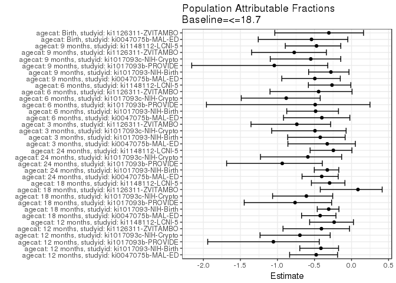

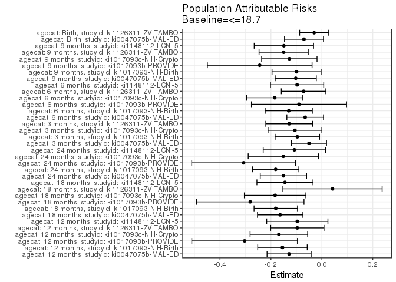

## Data Summary

| agecat | studyid | A | n | nA | nAY0 | nAY1 |
| --- | --- | --- | --- | --- | --- | --- |
| Birth | ki0047075b-MAL-ED | <=18.7 | 1425 | 105 | 84 | 21 |
| Birth | ki0047075b-MAL-ED | (18.7-20.67] | 1425 | 176 | 146 | 30 |
| Birth | ki0047075b-MAL-ED | (20.67-23.47] | 1425 | 381 | 332 | 49 |
| Birth | ki0047075b-MAL-ED | >23.47 | 1425 | 763 | 678 | 85 |
| Birth | ki1017093-NIH-Birth | <=18.7 | 28 | 10 | 10 | 0 |
| Birth | ki1017093-NIH-Birth | (18.7-20.67] | 28 | 9 | 9 | 0 |
| Birth | ki1017093-NIH-Birth | (20.67-23.47] | 28 | 6 | 5 | 1 |
| Birth | ki1017093-NIH-Birth | >23.47 | 28 | 3 | 3 | 0 |
| Birth | ki1017093b-PROVIDE | <=18.7 | 0 | 0 | 0 | 0 |
| Birth | ki1017093b-PROVIDE | (18.7-20.67] | 0 | 0 | 0 | 0 |
| Birth | ki1017093b-PROVIDE | (20.67-23.47] | 0 | 0 | 0 | 0 |
| Birth | ki1017093b-PROVIDE | >23.47 | 0 | 0 | 0 | 0 |
| Birth | ki1017093c-NIH-Crypto | <=18.7 | 27 | 7 | 6 | 1 |
| Birth | ki1017093c-NIH-Crypto | (18.7-20.67] | 27 | 5 | 3 | 2 |
| Birth | ki1017093c-NIH-Crypto | (20.67-23.47] | 27 | 8 | 6 | 2 |
| Birth | ki1017093c-NIH-Crypto | >23.47 | 27 | 7 | 7 | 0 |
| Birth | ki1066203-TanzaniaChild2 | <=18.7 | 0 | 0 | 0 | 0 |
| Birth | ki1066203-TanzaniaChild2 | (18.7-20.67] | 0 | 0 | 0 | 0 |
| Birth | ki1066203-TanzaniaChild2 | (20.67-23.47] | 0 | 0 | 0 | 0 |
| Birth | ki1066203-TanzaniaChild2 | >23.47 | 0 | 0 | 0 | 0 |
| Birth | ki1126311-ZVITAMBO | <=18.7 | 2383 | 132 | 115 | 17 |
| Birth | ki1126311-ZVITAMBO | (18.7-20.67] | 2383 | 436 | 384 | 52 |
| Birth | ki1126311-ZVITAMBO | (20.67-23.47] | 2383 | 846 | 756 | 90 |
| Birth | ki1126311-ZVITAMBO | >23.47 | 2383 | 969 | 893 | 76 |
| Birth | ki1148112-LCNI-5 | <=18.7 | 0 | 0 | 0 | 0 |
| Birth | ki1148112-LCNI-5 | (18.7-20.67] | 0 | 0 | 0 | 0 |
| Birth | ki1148112-LCNI-5 | (20.67-23.47] | 0 | 0 | 0 | 0 |
| Birth | ki1148112-LCNI-5 | >23.47 | 0 | 0 | 0 | 0 |
| 3 months | ki0047075b-MAL-ED | <=18.7 | 1759 | 132 | 105 | 27 |
| 3 months | ki0047075b-MAL-ED | (18.7-20.67] | 1759 | 229 | 190 | 39 |

[output cut: 166 more lines]

## Results Table

### Parameter: TSM

| agecat | studyid | intervention_level | baseline_level | estimate | ci_lower | ci_upper |
| --- | --- | --- | --- | --- | --- | --- |
| Birth | ki0047075b-MAL-ED | <=18.7 | NA | 0.2000000 | 0.1234640 | 0.2765360 |
| Birth | ki0047075b-MAL-ED | (18.7-20.67] | NA | 0.1704545 | 0.1148809 | 0.2260282 |
| Birth | ki0047075b-MAL-ED | (20.67-23.47] | NA | 0.1286089 | 0.0949825 | 0.1622353 |
| Birth | ki0047075b-MAL-ED | >23.47 | NA | 0.1114024 | 0.0890698 | 0.1337349 |
| Birth | ki1126311-ZVITAMBO | <=18.7 | NA | 0.1287879 | 0.0716332 | 0.1859425 |
| Birth | ki1126311-ZVITAMBO | (18.7-20.67] | NA | 0.1192661 | 0.0888378 | 0.1496943 |
| Birth | ki1126311-ZVITAMBO | (20.67-23.47] | NA | 0.1063830 | 0.0856020 | 0.1271639 |
| Birth | ki1126311-ZVITAMBO | >23.47 | NA | 0.0784314 | 0.0615002 | 0.0953625 |
| 3 months | ki0047075b-MAL-ED | <=18.7 | NA | 0.2045455 | 0.1357140 | 0.2733770 |
| 3 months | ki0047075b-MAL-ED | (18.7-20.67] | NA | 0.1703057 | 0.1216058 | 0.2190055 |
| 3 months | ki0047075b-MAL-ED | (20.67-23.47] | NA | 0.1573499 | 0.1248670 | 0.1898328 |
| 3 months | ki0047075b-MAL-ED | >23.47 | NA | 0.1409836 | 0.1184284 | 0.1635388 |
| 3 months | ki1017093-NIH-Birth | <=18.7 | NA | 0.3243243 | 0.2371624 | 0.4114862 |
| 3 months | ki1017093-NIH-Birth | (18.7-20.67] | NA | 0.2073171 | 0.1452195 | 0.2694147 |
| 3 months | ki1017093-NIH-Birth | (20.67-23.47] | NA | 0.1812865 | 0.1234929 | 0.2390802 |
| 3 months | ki1017093-NIH-Birth | >23.47 | NA | 0.2338710 | 0.1593021 | 0.3084399 |
| 3 months | ki1017093c-NIH-Crypto | <=18.7 | NA | 0.3200000 | 0.2143559 | 0.4256441 |
| 3 months | ki1017093c-NIH-Crypto | (18.7-20.67] | NA | 0.2325581 | 0.1596056 | 0.3055106 |
| 3 months | ki1017093c-NIH-Crypto | (20.67-23.47] | NA | 0.1866667 | 0.1357192 | 0.2376142 |
| 3 months | ki1017093c-NIH-Crypto | >23.47 | NA | 0.2006689 | 0.1552419 | 0.2460959 |
| 3 months | ki1126311-ZVITAMBO | <=18.7 | NA | 0.3020833 | 0.2102098 | 0.3939569 |
| 3 months | ki1126311-ZVITAMBO | (18.7-20.67] | NA | 0.2388060 | 0.1931383 | 0.2844737 |
| 3 months | ki1126311-ZVITAMBO | (20.67-23.47] | NA | 0.1858790 | 0.1569295 | 0.2148285 |
| 3 months | ki1126311-ZVITAMBO | >23.47 | NA | 0.1204517 | 0.0978486 | 0.1430548 |
| 6 months | ki0047075b-MAL-ED | <=18.7 | NA | 0.2290076 | 0.1570311 | 0.3009842 |
| 6 months | ki0047075b-MAL-ED | (18.7-20.67] | NA | 0.2009346 | 0.1472328 | 0.2546363 |
| 6 months | ki0047075b-MAL-ED | (20.67-23.47] | NA | 0.1814255 | 0.1463128 | 0.2165382 |
| 6 months | ki0047075b-MAL-ED | >23.47 | NA | 0.1352273 | 0.1126267 | 0.1578278 |
| 6 months | ki1017093-NIH-Birth | <=18.7 | NA | 0.3981481 | 0.3057405 | 0.4905558 |
| 6 months | ki1017093-NIH-Birth | (18.7-20.67] | NA | 0.2516556 | 0.1823739 | 0.3209373 |

[output cut: 110 more lines]

### Parameter: E(Y)

| agecat | studyid | intervention_level | baseline_level | estimate | ci_lower | ci_upper |
| --- | --- | --- | --- | --- | --- | --- |
| Birth | ki0047075b-MAL-ED | NA | NA | 0.1298246 | 0.1284032 | 0.1312459 |
| Birth | ki1126311-ZVITAMBO | NA | NA | 0.0986152 | 0.0979018 | 0.0993285 |
| 3 months | ki0047075b-MAL-ED | NA | NA | 0.1540648 | 0.1532318 | 0.1548978 |
| 3 months | ki1017093-NIH-Birth | NA | NA | 0.2280702 | 0.2238869 | 0.2322534 |
| 3 months | ki1017093c-NIH-Crypto | NA | NA | 0.2142857 | 0.2114495 | 0.2171220 |
| 3 months | ki1126311-ZVITAMBO | NA | NA | 0.1737773 | 0.1714147 | 0.1761399 |
| 6 months | ki0047075b-MAL-ED | NA | NA | 0.1635071 | 0.1619864 | 0.1650278 |
| 6 months | ki1017093-NIH-Birth | NA | NA | 0.2681564 | 0.2625210 | 0.2737919 |
| 6 months | ki1017093b-PROVIDE | NA | NA | 0.1830065 | 0.1761132 | 0.1898999 |
| 6 months | ki1017093c-NIH-Crypto | NA | NA | 0.2097902 | 0.2049372 | 0.2146432 |
| 6 months | ki1126311-ZVITAMBO | NA | NA | 0.1615646 | 0.1604972 | 0.1626320 |
| 6 months | ki1148112-LCNI-5 | NA | NA | 0.3686747 | 0.3616877 | 0.3756617 |
| 9 months | ki0047075b-MAL-ED | NA | NA | 0.2069810 | 0.2051187 | 0.2088433 |
| 9 months | ki1017093-NIH-Birth | NA | NA | 0.3570020 | 0.3521549 | 0.3618490 |
| 9 months | ki1017093b-PROVIDE | NA | NA | 0.2341772 | 0.2154630 | 0.2528914 |
| 9 months | ki1017093c-NIH-Crypto | NA | NA | 0.2322946 | 0.2282534 | 0.2363359 |
| 9 months | ki1126311-ZVITAMBO | NA | NA | 0.1940120 | 0.1917767 | 0.1962473 |
| 9 months | ki1148112-LCNI-5 | NA | NA | 0.3156250 | 0.3062570 | 0.3249930 |
| 12 months | ki0047075b-MAL-ED | NA | NA | 0.2697328 | 0.2671201 | 0.2723454 |
| 12 months | ki1017093-NIH-Birth | NA | NA | 0.3747454 | 0.3675917 | 0.3818991 |
| 12 months | ki1017093b-PROVIDE | NA | NA | 0.2875817 | 0.2635134 | 0.3116500 |
| 12 months | ki1017093c-NIH-Crypto | NA | NA | 0.2422096 | 0.2375649 | 0.2468543 |
| 12 months | ki1126311-ZVITAMBO | NA | NA | 0.2370779 | 0.2351418 | 0.2390140 |
| 12 months | ki1148112-LCNI-5 | NA | NA | 0.4110032 | 0.4016921 | 0.4203143 |
| 18 months | ki0047075b-MAL-ED | NA | NA | 0.3863636 | 0.3822635 | 0.3904638 |
| 18 months | ki1017093-NIH-Birth | NA | NA | 0.5874730 | 0.5787181 | 0.5962279 |
| 18 months | ki1017093b-PROVIDE | NA | NA | 0.3687943 | 0.3456883 | 0.3919003 |
| 18 months | ki1017093c-NIH-Crypto | NA | NA | 0.3012618 | 0.2959445 | 0.3065791 |
| 18 months | ki1126311-ZVITAMBO | NA | NA | 0.4818942 | 0.4767402 | 0.4870481 |
| 18 months | ki1148112-LCNI-5 | NA | NA | 0.4901408 | 0.4818606 | 0.4984211 |
| 24 months | ki0047075b-MAL-ED | NA | NA | 0.3749157 | 0.3706049 | 0.3792265 |
| 24 months | ki1017093-NIH-Birth | NA | NA | 0.5547786 | 0.5457419 | 0.5638153 |
| 24 months | ki1017093b-PROVIDE | NA | NA | 0.3288591 | 0.3011724 | 0.3565457 |
| 24 months | ki1017093c-NIH-Crypto | NA | NA | 0.2568093 | 0.2507080 | 0.2629107 |
| 24 months | ki1148112-LCNI-5 | NA | NA | 0.4391892 | 0.4277656 | 0.4506128 |

### Parameter: RR

| agecat | studyid | intervention_level | baseline_level | estimate | ci_lower | ci_upper |
| --- | --- | --- | --- | --- | --- | --- |
| Birth | ki0047075b-MAL-ED | (18.7-20.67] | <=18.7 | 0.8522727 | 0.5155185 | 1.4090062 |
| Birth | ki0047075b-MAL-ED | (20.67-23.47] | <=18.7 | 0.6430446 | 0.4045364 | 1.0221734 |
| Birth | ki0047075b-MAL-ED | >23.47 | <=18.7 | 0.5570118 | 0.3616143 | 0.8579920 |
| Birth | ki1126311-ZVITAMBO | (18.7-20.67] | <=18.7 | 0.9260658 | 0.5550439 | 1.5450993 |
| Birth | ki1126311-ZVITAMBO | (20.67-23.47] | <=18.7 | 0.8260325 | 0.5086478 | 1.3414582 |
| Birth | ki1126311-ZVITAMBO | >23.47 | <=18.7 | 0.6089965 | 0.3717811 | 0.9975677 |
| 3 months | ki0047075b-MAL-ED | (18.7-20.67] | <=18.7 | 0.8326055 | 0.5353718 | 1.2948607 |
| 3 months | ki0047075b-MAL-ED | (20.67-23.47] | <=18.7 | 0.7692662 | 0.5183508 | 1.1416409 |
| 3 months | ki0047075b-MAL-ED | >23.47 | <=18.7 | 0.6892532 | 0.4748528 | 1.0004574 |
| 3 months | ki1017093-NIH-Birth | (18.7-20.67] | <=18.7 | 0.6392276 | 0.4274502 | 0.9559288 |
| 3 months | ki1017093-NIH-Birth | (20.67-23.47] | <=18.7 | 0.5589669 | 0.3683846 | 0.8481460 |
| 3 months | ki1017093-NIH-Birth | >23.47 | <=18.7 | 0.7211022 | 0.4752213 | 1.0942024 |
| 3 months | ki1017093c-NIH-Crypto | (18.7-20.67] | <=18.7 | 0.7267442 | 0.4608935 | 1.1459418 |
| 3 months | ki1017093c-NIH-Crypto | (20.67-23.47] | <=18.7 | 0.5833333 | 0.3800904 | 0.8952550 |
| 3 months | ki1017093c-NIH-Crypto | >23.47 | <=18.7 | 0.6270903 | 0.4202262 | 0.9357871 |
| 3 months | ki1126311-ZVITAMBO | (18.7-20.67] | <=18.7 | 0.7905301 | 0.5519428 | 1.1322511 |
| 3 months | ki1126311-ZVITAMBO | (20.67-23.47] | <=18.7 | 0.6153235 | 0.4372287 | 0.8659608 |
| 3 months | ki1126311-ZVITAMBO | >23.47 | <=18.7 | 0.3987366 | 0.2789228 | 0.5700177 |
| 6 months | ki0047075b-MAL-ED | (18.7-20.67] | <=18.7 | 0.8774143 | 0.5808039 | 1.3255006 |
| 6 months | ki0047075b-MAL-ED | (20.67-23.47] | <=18.7 | 0.7922246 | 0.5477056 | 1.1459073 |
| 6 months | ki0047075b-MAL-ED | >23.47 | <=18.7 | 0.5904924 | 0.4136357 | 0.8429671 |
| 6 months | ki1017093-NIH-Birth | (18.7-20.67] | <=18.7 | 0.6320653 | 0.4409405 | 0.9060327 |
| 6 months | ki1017093-NIH-Birth | (20.67-23.47] | <=18.7 | 0.5928066 | 0.4126476 | 0.8516217 |
| 6 months | ki1017093-NIH-Birth | >23.47 | <=18.7 | 0.5366726 | 0.3532429 | 0.8153526 |
| 6 months | ki1017093b-PROVIDE | (18.7-20.67] | <=18.7 | 0.7521368 | 0.2986876 | 1.8939847 |
| 6 months | ki1017093b-PROVIDE | (20.67-23.47] | <=18.7 | 0.5347222 | 0.2027430 | 1.4102971 |
| 6 months | ki1017093b-PROVIDE | >23.47 | <=18.7 | 0.5833333 | 0.2220125 | 1.5326967 |
| 6 months | ki1017093c-NIH-Crypto | (18.7-20.67] | <=18.7 | 0.5629630 | 0.3663965 | 0.8649845 |
| 6 months | ki1017093c-NIH-Crypto | (20.67-23.47] | <=18.7 | 0.4299694 | 0.2868118 | 0.6445820 |
| 6 months | ki1017093c-NIH-Crypto | >23.47 | <=18.7 | 0.4723164 | 0.3273034 | 0.6815780 |

[output cut: 75 more lines]

### Parameter: PAR

| agecat | studyid | intervention_level | baseline_level | estimate | ci_lower | ci_upper |
| --- | --- | --- | --- | --- | --- | --- |
| Birth | ki0047075b-MAL-ED | <=18.7 | NA | -0.0701754 | -0.1467247 | 0.0063738 |
| Birth | ki1126311-ZVITAMBO | <=18.7 | NA | -0.0301727 | -0.0873318 | 0.0269864 |
| 3 months | ki0047075b-MAL-ED | <=18.7 | NA | -0.0504806 | -0.1193172 | 0.0183559 |
| 3 months | ki1017093-NIH-Birth | <=18.7 | NA | -0.0962541 | -0.1835164 | -0.0089919 |
| 3 months | ki1017093c-NIH-Crypto | <=18.7 | NA | -0.1057143 | -0.2113965 | -0.0000321 |
| 3 months | ki1126311-ZVITAMBO | <=18.7 | NA | -0.1283060 | -0.2202100 | -0.0364021 |
| 6 months | ki0047075b-MAL-ED | <=18.7 | NA | -0.0655005 | -0.1374932 | 0.0064921 |
| 6 months | ki1017093-NIH-Birth | <=18.7 | NA | -0.1299917 | -0.2225711 | -0.0374124 |
| 6 months | ki1017093b-PROVIDE | <=18.7 | NA | -0.0897207 | -0.2765605 | 0.0971191 |
| 6 months | ki1017093c-NIH-Crypto | <=18.7 | NA | -0.1849466 | -0.2950229 | -0.0748704 |
| 6 months | ki1126311-ZVITAMBO | <=18.7 | NA | -0.0717687 | -0.1591813 | 0.0156439 |
| 6 months | ki1148112-LCNI-5 | <=18.7 | NA | -0.0972344 | -0.2018172 | 0.0073484 |
| 9 months | ki0047075b-MAL-ED | <=18.7 | NA | -0.1025428 | -0.1833096 | -0.0217760 |
| 9 months | ki1017093-NIH-Birth | <=18.7 | NA | -0.0993087 | -0.1957168 | -0.0029006 |
| 9 months | ki1017093b-PROVIDE | <=18.7 | NA | -0.2440837 | -0.4497332 | -0.0384341 |
| 9 months | ki1017093c-NIH-Crypto | <=18.7 | NA | -0.1277054 | -0.2364897 | -0.0189210 |
| 9 months | ki1126311-ZVITAMBO | <=18.7 | NA | -0.1500740 | -0.2466813 | -0.0534667 |
| 9 months | ki1148112-LCNI-5 | <=18.7 | NA | -0.1491637 | -0.2657362 | -0.0325913 |
| 12 months | ki0047075b-MAL-ED | <=18.7 | NA | -0.1286412 | -0.2152251 | -0.0420573 |
| 12 months | ki1017093-NIH-Birth | <=18.7 | NA | -0.1546663 | -0.2518933 | -0.0574394 |
| 12 months | ki1017093b-PROVIDE | <=18.7 | NA | -0.3033274 | -0.5108529 | -0.0958019 |
| 12 months | ki1017093c-NIH-Crypto | <=18.7 | NA | -0.1687493 | -0.2817896 | -0.0557090 |
| 12 months | ki1126311-ZVITAMBO | <=18.7 | NA | -0.0962555 | -0.2009246 | 0.0084137 |
| 12 months | ki1148112-LCNI-5 | <=18.7 | NA | -0.0964595 | -0.2167251 | 0.0238062 |
| 18 months | ki0047075b-MAL-ED | <=18.7 | NA | -0.1636364 | -0.2527709 | -0.0745018 |
| 18 months | ki1017093-NIH-Birth | <=18.7 | NA | -0.1809481 | -0.2663172 | -0.0955789 |
| 18 months | ki1017093b-PROVIDE | <=18.7 | NA | -0.2812057 | -0.4922569 | -0.0701545 |
| 18 months | ki1017093c-NIH-Crypto | <=18.7 | NA | -0.1835867 | -0.3043710 | -0.0628023 |
| 18 months | ki1126311-ZVITAMBO | <=18.7 | NA | 0.0418942 | -0.1530257 | 0.2368140 |
| 18 months | ki1148112-LCNI-5 | <=18.7 | NA | -0.1449943 | -0.2551418 | -0.0348468 |
| 24 months | ki0047075b-MAL-ED | <=18.7 | NA | -0.1509464 | -0.2419464 | -0.0599463 |
| 24 months | ki1017093-NIH-Birth | <=18.7 | NA | -0.1814852 | -0.2725778 | -0.0903925 |
| 24 months | ki1017093b-PROVIDE | <=18.7 | NA | -0.3075046 | -0.5110865 | -0.1039227 |
| 24 months | ki1017093c-NIH-Crypto | <=18.7 | NA | -0.1513539 | -0.2892387 | -0.0134691 |
| 24 months | ki1148112-LCNI-5 | <=18.7 | NA | -0.1076858 | -0.2303835 | 0.0150119 |

### Parameter: PAF

| agecat | studyid | intervention_level | baseline_level | estimate | ci_lower | ci_upper |
| --- | --- | --- | --- | --- | --- | --- |
| Birth | ki0047075b-MAL-ED | <=18.7 | NA | -0.5405405 | -1.2591080 | -0.0505320 |
| Birth | ki1126311-ZVITAMBO | <=18.7 | NA | -0.3059639 | -1.0355978 | 0.1621421 |
| 3 months | ki0047075b-MAL-ED | <=18.7 | NA | -0.3276585 | -0.8588720 | 0.0517491 |
| 3 months | ki1017093-NIH-Birth | <=18.7 | NA | -0.4220374 | -0.8616535 | -0.0862335 |
| 3 months | ki1017093c-NIH-Crypto | <=18.7 | NA | -0.4933333 | -1.0780166 | -0.0731601 |
| 3 months | ki1126311-ZVITAMBO | <=18.7 | NA | -0.7383358 | -1.3569424 | -0.2820896 |
| 6 months | ki0047075b-MAL-ED | <=18.7 | NA | -0.4005974 | -0.9180981 | -0.0227178 |
| 6 months | ki1017093-NIH-Birth | <=18.7 | NA | -0.4847608 | -0.8744156 | -0.1761077 |
| 6 months | ki1017093b-PROVIDE | <=18.7 | NA | -0.4902597 | -1.9582525 | 0.2492615 |
| 6 months | ki1017093c-NIH-Crypto | <=18.7 | NA | -0.8815789 | -1.4884468 | -0.4227105 |
| 6 months | ki1126311-ZVITAMBO | <=18.7 | NA | -0.4442105 | -1.1005907 | 0.0070678 |
| 6 months | ki1148112-LCNI-5 | <=18.7 | NA | -0.2637403 | -0.5822456 | -0.0093500 |
| 9 months | ki0047075b-MAL-ED | <=18.7 | NA | -0.4954212 | -0.9414449 | -0.1518662 |
| 9 months | ki1017093-NIH-Birth | <=18.7 | NA | -0.2781741 | -0.5791379 | -0.0345702 |
| 9 months | ki1017093b-PROVIDE | <=18.7 | NA | -1.0423032 | -2.1571879 | -0.3211131 |
| 9 months | ki1017093c-NIH-Crypto | <=18.7 | NA | -0.5497561 | -1.0971272 | -0.1452543 |
| 9 months | ki1126311-ZVITAMBO | <=18.7 | NA | -0.7735298 | -1.3487845 | -0.3391641 |
| 9 months | ki1148112-LCNI-5 | <=18.7 | NA | -0.4725980 | -0.8941688 | -0.1448529 |
| 12 months | ki0047075b-MAL-ED | <=18.7 | NA | -0.4769211 | -0.8356886 | -0.1882712 |
| 12 months | ki1017093-NIH-Birth | <=18.7 | NA | -0.4127238 | -0.6983631 | -0.1751247 |
| 12 months | ki1017093b-PROVIDE | <=18.7 | NA | -1.0547521 | -1.9413884 | -0.4353786 |
| 12 months | ki1017093c-NIH-Crypto | <=18.7 | NA | -0.6967075 | -1.2348862 | -0.2881266 |
| 12 months | ki1126311-ZVITAMBO | <=18.7 | NA | -0.4060078 | -0.9247847 | -0.0270540 |
| 12 months | ki1148112-LCNI-5 | <=18.7 | NA | -0.2346927 | -0.5654737 | 0.0261951 |
| 18 months | ki0047075b-MAL-ED | <=18.7 | NA | -0.4235294 | -0.6742713 | -0.2103391 |
| 18 months | ki1017093-NIH-Birth | <=18.7 | NA | -0.3080108 | -0.4623122 | -0.1699912 |
| 18 months | ki1017093b-PROVIDE | <=18.7 | NA | -0.7625000 | -1.4485614 | -0.2686659 |
| 18 months | ki1017093c-NIH-Crypto | <=18.7 | NA | -0.6093924 | -1.0654703 | -0.2540213 |
| 18 months | ki1126311-ZVITAMBO | <=18.7 | NA | 0.0869364 | -0.4219428 | 0.4137000 |
| 18 months | ki1148112-LCNI-5 | <=18.7 | NA | -0.2958217 | -0.5417238 | -0.0891405 |
| 24 months | ki0047075b-MAL-ED | <=18.7 | NA | -0.4026141 | -0.6679156 | -0.1795119 |
| 24 months | ki1017093-NIH-Birth | <=18.7 | NA | -0.3271309 | -0.5026118 | -0.1721432 |
| 24 months | ki1017093b-PROVIDE | <=18.7 | NA | -0.9350649 | -1.6860568 | -0.3940421 |
| 24 months | ki1017093c-NIH-Crypto | <=18.7 | NA | -0.5893630 | -1.2292283 | -0.1331611 |
| 24 months | ki1148112-LCNI-5 | <=18.7 | NA | -0.2451923 | -0.5592208 | 0.0055906 |